# A DESeq2 Bulk RNASeq analysis

## 20th November 2025

Using DESeq2 to run differential gene expression analysis on matched normal vs tumour samples from 5 patients: S02, S03, S05, S06 and S10.

## Loading packages

```r
#Load packages

library(DESeq2)
library(pheatmap)
library(tidyverse)
library(ggrepel)


#For Gene Set Enrichment Analysis
library(fgsea)
library(data.table)
library(qusage)
```

## Load input files for DESeq2 analysis

Counts data must be in WHOLE NUMBERS, i.e integers. In this case, they are.

```r
the_counts <- read.table("omics_data/row_count_data.nodup.txt", header = T, sep = "", row.names = 1)
#Important to assign the gene names as the rownames of the dataframe

head(the_counts) #Confirming that counts numeric values are in integer format
```

```
##        S02_Normal S03_Normal S05_Normal S06_Normal S10_Normal S02_Tumour
## CHAC1           0          1          1          0         29         81
## GLRX          688        669        442        187       1138        153
## MEFV           35         13          0         18         58         37
## STXBP1         84         43        116        118        121        171
## AKAP8L         27         18         27         45         96         26
## AKR1C1        120         24         34         65        103        548
##        S03_Tumour S05_Tumour S06_Tumour S10_Tumour
## CHAC1           7         69         35         12
## GLRX          181         64          0        150
## MEFV            0         50          0         15
## STXBP1         57         89         43         60
## AKAP8L          0         41          0         24
## AKR1C1         22          0          0         13
```

The sample metadata contains information about the patient ID and the experimental condition being assessed, i.e. normal vs tumour sample.

```r
#Loading in the sample metadata
sample_data <- read.table("omics_data/sample_groups.txt", header = T, sep = "", row.names = 1)
head(sample_data)
```

```
##             Group Patient
## S02_Normal Normal     S02
## S03_Normal Normal     S03
## S05_Normal Normal     S05
## S06_Normal Normal     S06
## S10_Normal Normal     S10
## S02_Tumour Tumour     S02
```

Confirming that columns in the counts matrix AND rows of the sample data are in the same order before proceeding.

```r
all(rownames(sample_data) %in% colnames(the_counts))
```

```
## [1] TRUE
```

```r
all(rownames(sample_data) == colnames(the_counts))
```

```
## [1] TRUE
```

## All good. Now to create a DESeqObject.

Because normal and tumour samples were matched from the same patients, I accounted for the multi-factor design and implemented pair sample analysis when creating the DESeq object. In the following code below, the design parameter accounts for the patient ID, while keeping to differential gene expression for the “Group” condition, i.e. normal vs tumour.

```r
dds_Obj <- DESeqDataSetFromMatrix(countData = the_counts,
                                  colData = sample_data,
                                  design = ~ Patient + Group)
dds_Obj
```

```
## class: DESeqDataSet
## dim: 19701 10
## metadata(1): version
## assays(1): counts
## rownames(19701): CHAC1 GLRX ... G3BP1 RPS18
## rowData names(0):
## colnames(10): S02_Normal S03_Normal ... S06_Tumour S10_Tumour
## colData names(2): Group Patient
```

Applying filtering step to remove low quality reads. Retaining samples with gene counts of at least 10 or above.

```r
sample_groupSize <- 5 # Based on 5 samples per condition (normal vs tumour)
keeping <- rowSums(counts(dds_Obj) >= 10) >= sample_groupSize #Total counts per gene >= 10 in 5 or more samples

dds_Obj <- dds_Obj[keeping, ] #subsetting based on the above value

dds_Obj
```

```
## class: DESeqDataSet
## dim: 12403 10
## metadata(1): version
## assays(1): counts
## rownames(12403): CHAC1 GLRX ... G3BP1 RPS18
## rowData names(0):
## colnames(10): S02_Normal S03_Normal ... S06_Tumour S10_Tumour
## colData names(2): Group Patient
```

Gene counts filtered from 19701 to 12403.

DESeq2 will default to a reference level based on alphabetical order, determining the control conditions and test condition. For good measure, to specify the control and experimental/test condition for differential gene expression, I set the factor level, with “Normal” being the control condition.

```r
dds_Obj$Group <- relevel(dds_Obj$Group, ref = "Normal")
dds_Obj$Group
```

```
##  [1] Normal Normal Normal Normal Normal Tumour Tumour Tumour Tumour Tumour
## Levels: Normal Tumour
```

## Now to run the DESEq2

```r
dds_Obj <- DESeq(dds_Obj)
dds_Obj
```

```
## class: DESeqDataSet
## dim: 12403 10
## metadata(1): version
## assays(4): counts mu H cooks
## rownames(12403): CHAC1 GLRX ... G3BP1 RPS18
## rowData names(38): baseMean baseVar ... deviance maxCooks
## colnames(10): S02_Normal S03_Normal ... S06_Tumour S10_Tumour
## colData names(3): Group Patient sizeFactor
```

## Obtaining the results from each condition (tumour vs normal)

```r
results_ddsObj <- results(dds_Obj, contrast = c("Group", "Tumour", "Normal"))
results_ddsObj
```

```
## log2 fold change (MLE): Group Tumour vs Normal
## Wald test p-value: Group Tumour vs Normal
## DataFrame with 12403 rows and 6 columns
##          baseMean log2FoldChange     lfcSE      stat      pvalue        padj
##         <numeric>      <numeric> <numeric> <numeric>   <numeric>   <numeric>
## CHAC1     20.6186       5.102741  1.418925  3.596202 3.22897e-04 7.12614e-03
## GLRX     363.6835      -3.066369  0.603336 -5.082354 3.72786e-07 4.71802e-05
## MEFV      18.9413      -1.756540  1.681455 -1.044655 2.96182e-01 5.30549e-01
## STXBP1    81.4661      -0.178891  0.463813 -0.385697 6.99721e-01 8.44072e-01
## AKAP8L    25.9880      -2.227985  1.248938 -1.783905 7.44392e-02 2.43542e-01
## ...           ...            ...       ...       ...         ...         ...
## GAPDH  1163.99467       0.373840  0.257840  1.449892 0.147088702  0.35785429
## RPL23A  528.35453      -1.304126  0.340111 -3.834415 0.000125863  0.00364739
## TPI1     28.60918       1.033096  0.698310  1.479423 0.139027367  0.34737237
## G3BP1   508.11307      -0.259042  0.429321 -0.603376 0.546258904  0.74290013
## RPS18     7.28172      -2.781478  1.813665 -1.533623 0.125122409  0.32637082
```

Positive values of log2FoldChange = upregulated genes in the “tumour” condition

Negative values of log2FoldChange = downregulated genes in the “tumour” condition

```r
#Output of summary data
DESeq2::summary(results_ddsObj)
```

```
##
## out of 12403 with nonzero total read count
## adjusted p-value < 0.1
## LFC > 0 (up)       : 740, 6%
## LFC < 0 (down)     : 1351, 11%
## outliers [1]       : 0, 0%
## low counts [2]     : 0, 0%
## (mean count < 5)
## [1] see 'cooksCutoff' argument of ?results
## [2] see 'independentFiltering' argument of ?results
```

From the LFC (log2 fold change) results in the summary output:

740 genes upregulated in tumour sample, compared to normal. 1351 genes downregulated in tumour sample, compared to normal.

```r
#Retrieving metadata columns and its corresponding info
mcols(results_ddsObj)$description
```

```
## [1] "mean of normalized counts for all samples"
## [2] "log2 fold change (MLE): Group Tumour vs Normal"
## [3] "standard error: Group Tumour vs Normal"
## [4] "Wald statistic: Group Tumour vs Normal"
## [5] "Wald test p-value: Group Tumour vs Normal"
## [6] "BH adjusted p-values"
```

## Plot counts

Visualising counts across the normal vs tumour group. In the below point, this outputs the most significantly expressed gene, i.e the smallest adjusted p-value, between the “tumour” and “normal” condition.

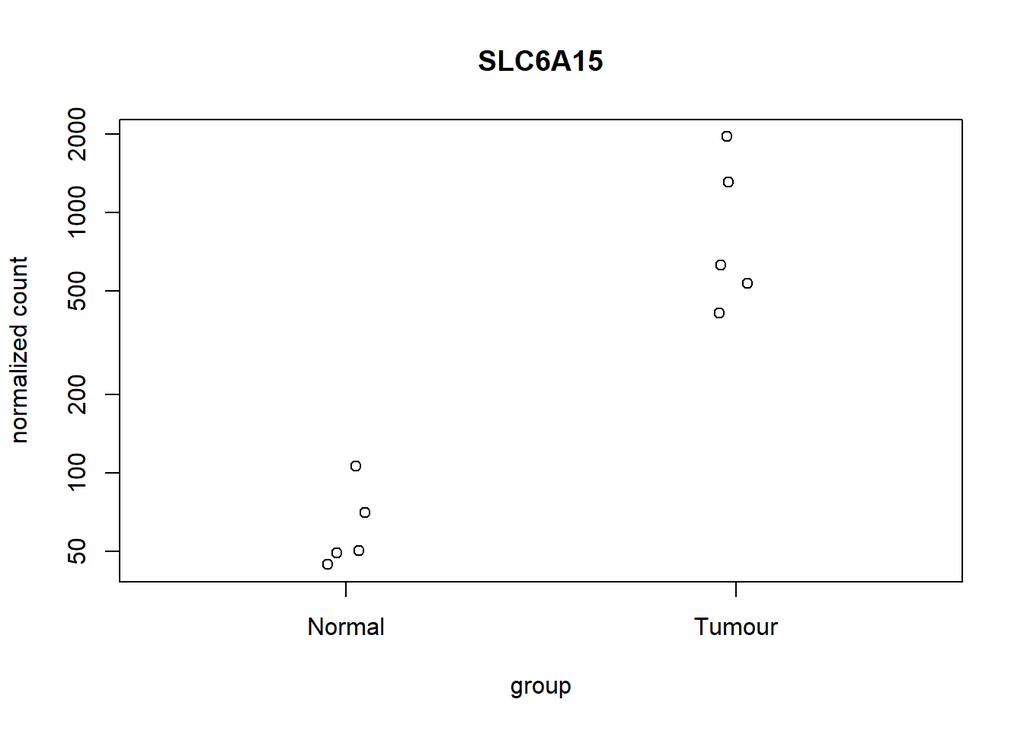

```r
plotCounts(dds_Obj, gene = which.min(results_ddsObj$padj), intgroup = "Group")
```

Gene SLC6A15 most differentially expressed in tumour, compared to normal tissue.

## LFC shrinkage

Ashr and normal methods are best suited for LFC shrinkage when contrast is involved

```r
results_ashr <- lfcShrink(dds_Obj, contrast = c("Group", "Tumour", "Normal"), type = "ashr")
```

```
## using 'ashr' for LFC shrinkage. If used in published research, please cite:
##     Stephens, M. (2016) False discovery rates: a new deal. Biostatistics, 18:2.
##     https://doi.org/10.1093/biostatistics/kxw041
```

```r
results_normal <- lfcShrink(dds_Obj, contrast = c("Group", "Tumour", "Normal"), type = "normal")
```

```
## using 'normal' for LFC shrinkage, the Normal prior from Love et al (2014).
##
## Note that type='apeglm' and type='ashr' have shown to have less bias than type='normal'.
## See ?lfcShrink for more details on shrinkage type, and the DESeq2 vignette.
## Reference: https://doi.org/10.1093/bioinformatics/bty895
```

## MA plots

**Note: specifying the plotMA from DESEq2 package as R defaults to limma’s plotMA function when I ran the analysis.**

I generated MA plots to determine the distribution of the log2 fold changes with the different shrinkage methods. Blue points indicate padj values less than 0.1.

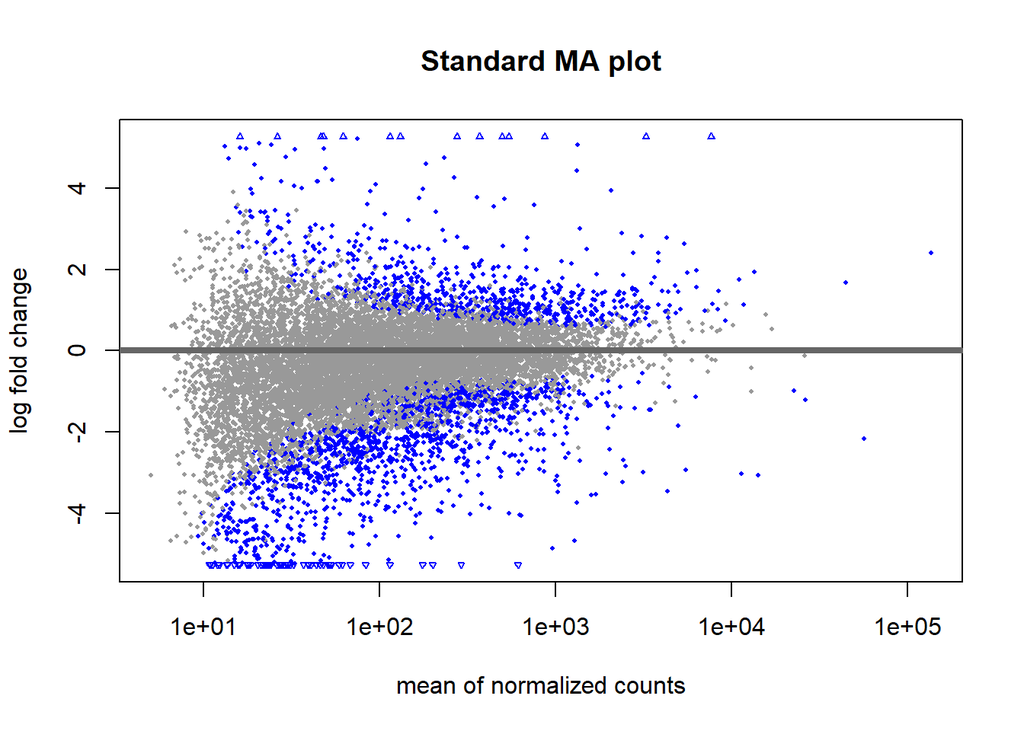

```r
DESeq2::plotMA(results_ddsObj, main = "Standard MA plot")
```

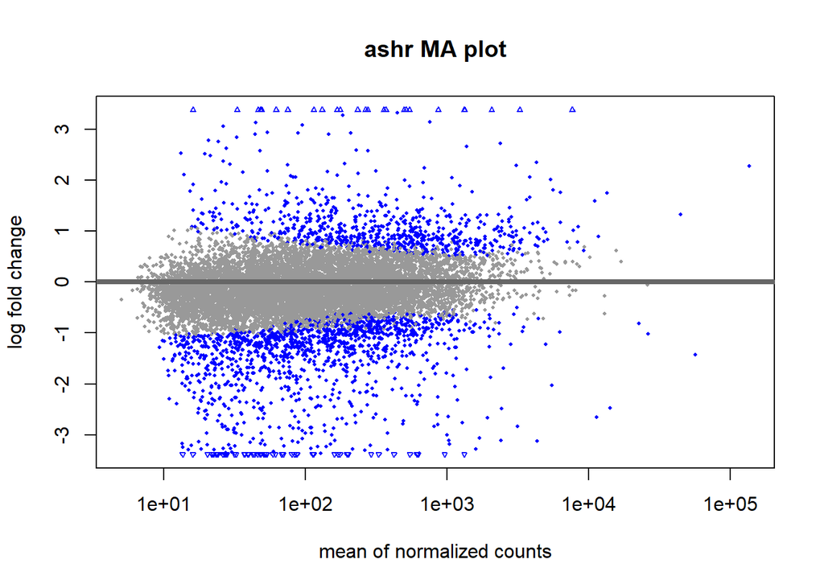

```r
DESeq2::plotMA(results_ashr, main = "ashr MA plot")
```

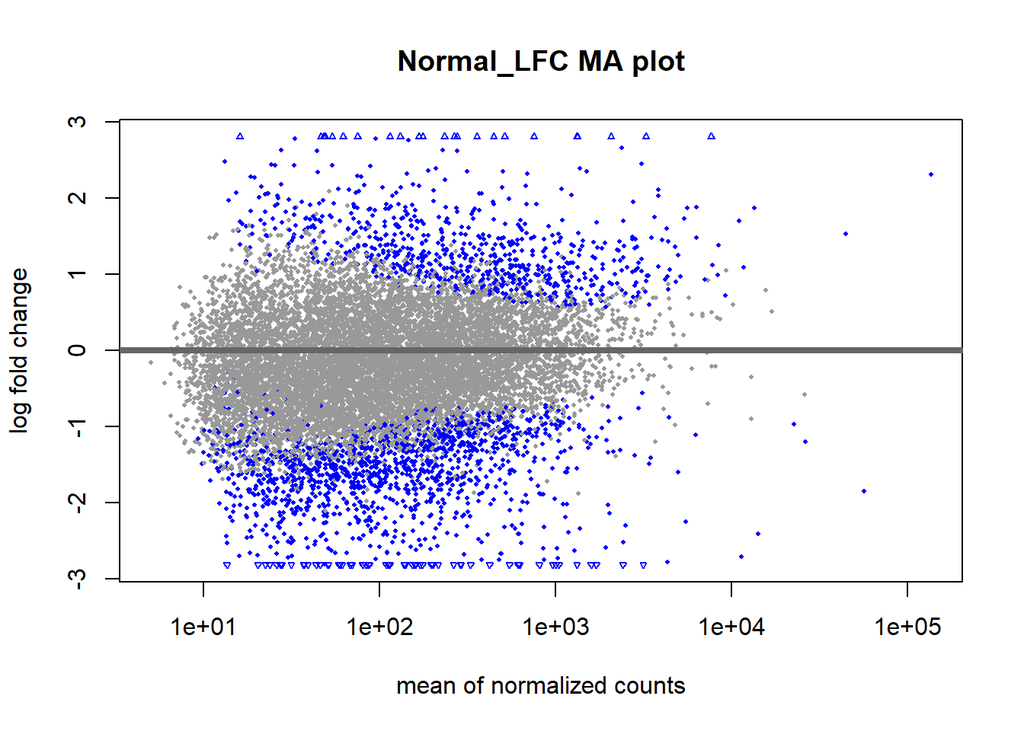

```r
DESeq2::plotMA(results_normal, main = "Normal_LFC MA plot")
```

In this case, I opted to use the **ashr shrunken data** for further analyses.

## Saving results as dataframe

```r
df_Ashr_res <- as.data.frame(results_ashr)

#Creating new column for gene names, since they're already in SYMBOL format
df_Ashr_res <- df_Ashr_res |>
  mutate(gene = rownames(df_Ashr_res), .before = 1)

head(df_Ashr_res)
```

```
##          gene  baseMean log2FoldChange     lfcSE       pvalue         padj
## CHAC1   CHAC1  20.61862      2.7838054 1.6109651 3.228969e-04 7.126139e-03
## GLRX     GLRX 363.68352     -2.7042223 0.6628408 3.727857e-07 4.718021e-05
## MEFV     MEFV  18.94127     -0.3082784 0.7555311 2.961824e-01 5.305485e-01
## STXBP1 STXBP1  81.46609     -0.1154168 0.3729179 6.997212e-01 8.440718e-01
## AKAP8L AKAP8L  25.98798     -0.6423017 0.8071903 7.443918e-02 2.435424e-01
## AKR1C1 AKR1C1  71.49405     -1.0170916 0.9439205 1.753797e-02 1.028966e-01
```

## Boxplot visualisation

Now to explore and visualise the data. Starting with boxplots to illustrate gene expression across the samples.

```r
# First, normalise the raw counts data
norm_counts <- counts(dds_Obj, normalized = T)
head(norm_counts, 3)
```

```
##       S02_Normal  S03_Normal  S05_Normal S06_Normal S10_Normal S02_Tumour
## CHAC1    0.00000    1.967858   0.8141559    0.00000   18.36927   56.58552
## GLRX   543.19896 1316.497185 359.8569084  168.53657  720.83561  106.88375
## MEFV    27.63367   25.582158   0.0000000   16.22277   36.73855   25.84771
##       S03_Tumour S05_Tumour S06_Tumour S10_Tumour
## CHAC1   7.141672   53.41418   52.94794   14.94555
## GLRX  184.663243   49.54359    0.00000  186.81942
## MEFV    0.000000   38.70593    0.00000   18.68194
```

### Normalised counts data boxplot (ggplot2 method)

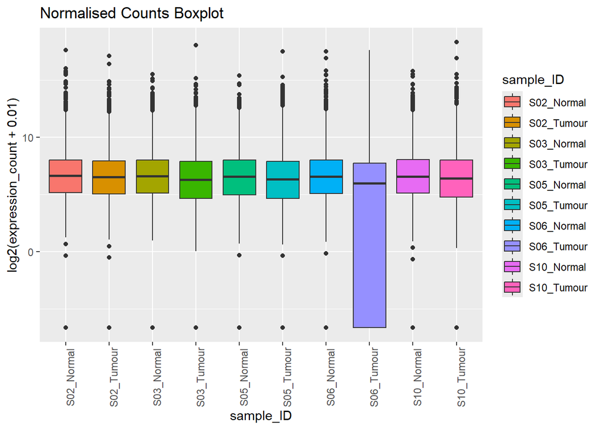

```r
df_normCounts <- as.data.frame(norm_counts)

#Pivoting dataframe for generating boxplot using ggplot2
long_normCounts <- df_normCounts |>
  rownames_to_column(var = "gene") |> #Setting rowname genes into a defined column
  pivot_longer(cols = !gene,
               names_to = "sample_ID", #putting all sample IDs into one column
               values_to = "expression_count")
#The boxplot
long_normCounts |>
  ggplot(aes(x = sample_ID, y = log2(expression_count + 0.01), fill = sample_ID)) + #adding 0.01 to account for zero values
  geom_boxplot() + labs(title = "Normalised Counts Boxplot") + theme(axis.text.x = element_text(angle = 90))
```

### VST data (ggplot2 method)

I included the transformed data using vst method (variance stabilising transformation) to see how the boxplot would pan out.

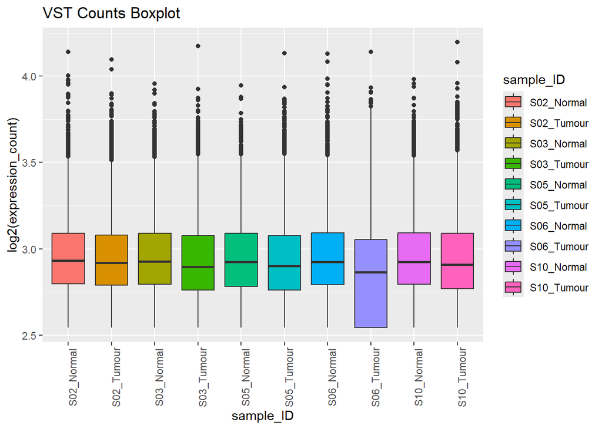

```r
#Transform the data using vst method
vst_ddsObj <- vst(dds_Obj, blind = F)

#Creating data frame by extracting the transformed counts using the assay() function
df_vstObj <- as.data.frame(assay(vst_ddsObj))

#Pivoting dataframe for generating boxplot using ggplot2
long_vstObj <- df_vstObj |>
  rownames_to_column(var = "gene") |> #Setting rowname genes into a defined column
  pivot_longer(cols = !gene,
               names_to = "sample_ID", #putting all sample IDs into one column
               values_to = "expression_count")
#The boxplot
long_vstObj |>
  ggplot(aes(x = sample_ID, y = log2(expression_count), fill = sample_ID)) +
  geom_boxplot() + labs(title = "VST Counts Boxplot") + theme(axis.text.x = element_text(angle = 90))
```

There seems to be great variance in expression count for Patient 6’s tumour sample.

## Plotting PCA

The following graph uses Principal Component Analysis, displaying the principal components based on the effects of the experimental conditions on gene expression. This also accounts for patient sample differences.

```
## using ntop=500 top features by variance
```

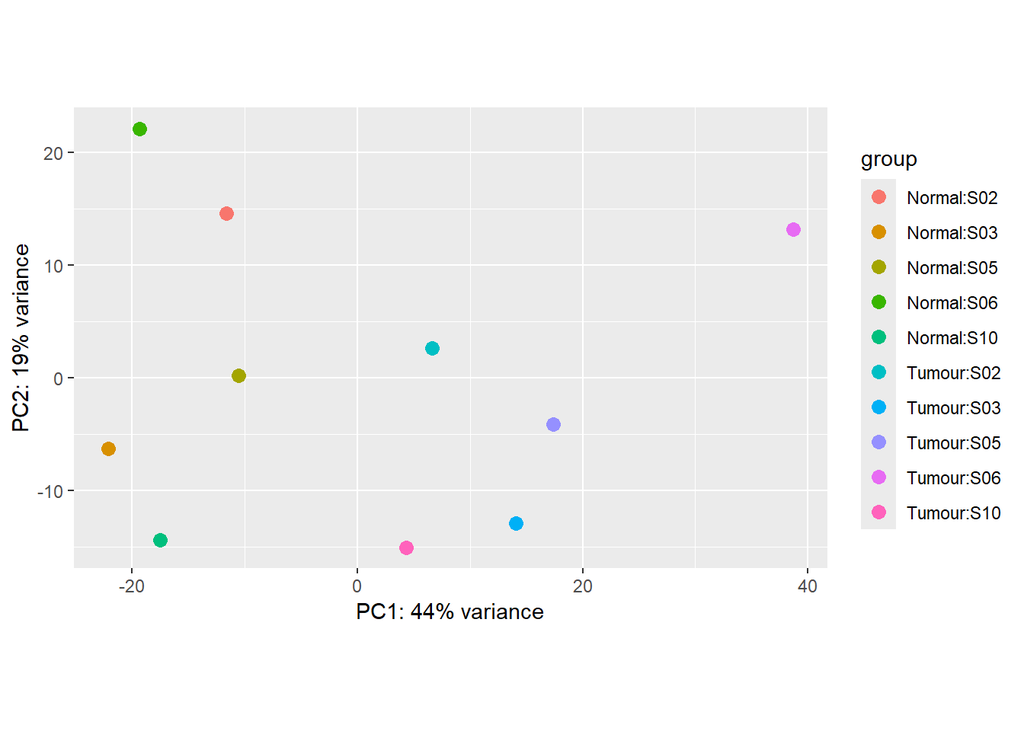

```r
plotPCA(vst_ddsObj, intgroup = c("Group", "Patient"))
```

## Top 10 most differentially expressed genes

The output of the top 10 most differentially expressed genes between tumour and normal samples. Using the padj values to subset for these genes of interest.

```r
top10_DGE <- df_Ashr_res |> arrange(padj) |>
  filter(padj < 0.05) |> slice_head(n = 10)

top10_DGE
```

```
##            gene  baseMean log2FoldChange     lfcSE       pvalue         padj
## SLC6A15 SLC6A15  513.9151       3.605738 0.4003467 2.111072e-20 2.618362e-16
## DAPL1     DAPL1  807.8418      -2.838014 0.3373880 1.801373e-18 1.117121e-14
## PTGS2     PTGS2  266.0492       4.048076 0.4839974 4.631031e-18 1.914623e-14
## SPINK6   SPINK6  275.5827       6.684848 0.8702866 3.880243e-17 1.203166e-13
## CLEC3B   CLEC3B 2409.1998      -3.110801 0.3873191 6.627054e-17 1.643907e-13
## KRT15     KRT15 1043.5978      -3.181740 0.4018582 1.778865e-16 3.677211e-13
## TNS4       TNS4 5597.1001       1.809510 0.2591124 8.389576e-15 1.486513e-11
## LYVE1     LYVE1  137.4226      -2.924971 0.4224947 1.715631e-13 2.659871e-10
## PI16       PI16  610.0864      -5.805911 0.8771329 3.178768e-13 4.112444e-10
## CYBRD1   CYBRD1  854.8797      -2.602437 0.3883139 3.315685e-13 4.112444e-10
```

As seen above in the initial plotCounts graph, SLC6A15 is the most differentially expressed gene between tumour and normal samples. It has a log2 fold change over 1, suggesting that there is increased expression in tumour cells, in comparison to its normal sample variant.

## Volcano Plot visualisation

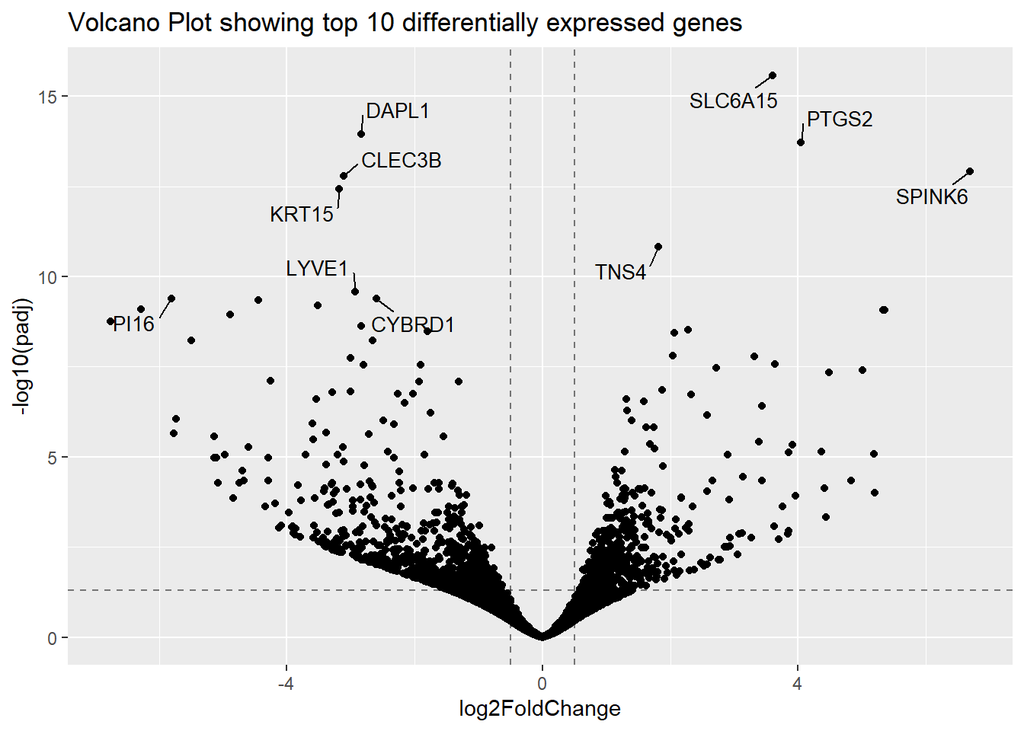

```r
df_Ashr_res |>
  ggplot(aes(x = log2FoldChange, y = -log10(padj))) +
  geom_point() +
  geom_hline(yintercept = -log10(0.05), linetype = "dashed", color = "black", alpha = 0.5) +
  geom_vline(xintercept = c(-0.5, 0.5), linetype = "dashed", color = "black", alpha = 0.5) +
  geom_text_repel(data = top10_DGE, aes(label = gene), size = 3.5,
                  box.padding = 0.5, max.overlaps = 20) +
  labs(title = "Volcano Plot showing top 10 differentially expressed genes")
```

Let’s look into what the upregulated genes are associated with, and how common they appear in cancer:

- **SLC6A15:** solute carrier family 6 member 15. Interestingly, this gene is a tumour suppressor, yet it is upregulated in the tumour samples. Perhaps genetic mutations from these sample cause dysregulated function? On the other hand, overexpression of this gene has been identified in some cancers, such as brain cancers.
- **PTGS2:** Prostaglandin-endoperoxide synthase 2. The encoded protein is involved in prostaglandin biosynthesis. Mutations in this gene, missense, silent, and nonsense, have been observed in various cancer indications, such as colorectal cancer.
- **SPINK6:** Serine peptidase inhibitor Kazal type 6. A prognostic marker of head and neck squamous cell carcinoma. It is associated with poor prognosis in a variety of malignancies.
- **TNS4:** Tensin-4. A study by Zheng et al 2025 highlights that TNS4 is a major driver of cancer progression.

## Heatmap data visualisation

From the vst data, below is a heatmap visualising the top 10 differentially expressed genes between tumour and normal samples.

```r
# A reminder
head(df_vstObj)
```

```
##        S02_Normal S03_Normal S05_Normal S06_Normal S10_Normal S02_Tumour
## CHAC1    5.826300   6.094588   5.999013   5.826300   6.636483   7.213023
## GLRX     9.348152  10.479500   8.865533   8.077336   9.697731   7.676883
## MEFV     6.813726   6.777686   5.826300   6.588815   6.957951   6.782439
## STXBP1   7.318620   7.493743   7.577982   7.672794   7.420669   7.769395
## AKAP8L   6.697305   6.938445   6.710378   7.012341   7.260084   6.632042
## AKR1C1   7.580479   7.100690   6.814545   7.235529   7.307410   8.935849
##        S03_Tumour S05_Tumour S06_Tumour S10_Tumour
## CHAC1    6.335487   7.176279   7.170768   6.558837
## GLRX     8.164520   7.129628   5.826300   8.175756
## MEFV     5.826300   6.986360   5.826300   6.643172
## STXBP1   7.230737   7.344953   7.305399   7.402401
## AKAP8L   5.826300   6.881622   5.826300   6.851708
## AKR1C1   6.719358   5.826300   5.826300   6.588085
```

```r
#Creating dataframe for column annotation. This is based on "tumour vs normal" condition
#from the sample metadata, which is called using the colData() function
column_ann_df <- as.data.frame(colData(dds_Obj)[,c("Group", "Patient")])

#Only interested in "Group", which specifies the tumour/normal experiment conditions
column_ann_df <- column_ann_df |> dplyr::select(Group)

#Extracting a list of the top 10 gene names
top10_list_genes <- top10_DGE$gene

#Extracting vst counts data based on above list
top10_vstObj <- assay(vst_ddsObj)[top10_list_genes, ]
top10_vstObj
```

```
##         S02_Normal S03_Normal S05_Normal S06_Normal S10_Normal S02_Tumour
## SLC6A15   7.358732   7.672143   7.121035   7.061048   7.135734   9.012961
## DAPL1    10.846744  11.004353   9.479555   9.398109  11.262370   7.832215
## PTGS2     6.997263   6.530144   6.626577   6.892804   6.255855   9.402316
## SPINK6    5.826300   5.826300   5.826300   6.269931   6.351436  10.509921
## CLEC3B   12.057756  11.147735  11.709424  13.294075  11.322513   9.437868
## KRT15    11.695762  11.241058  10.007778  10.932229  10.381768   8.248336
## TNS4     10.707759  11.016748  10.813329  11.485590  11.819695  12.631578
## LYVE1     8.663789   7.476128   8.186427   9.274493   7.981654   6.920454
## PI16      9.042775   9.525243   9.958891  11.916445   8.718647   7.289809
## CYBRD1   10.535577  10.643106  10.245564  11.227463  10.280871   8.991070
##         S03_Tumour S05_Tumour S06_Tumour S10_Tumour
## SLC6A15  11.008116   9.324297  10.463736   9.527628
## DAPL1     8.237249   7.577985   7.852791   8.793589
## PTGS2     9.832665   7.893187  10.075060   7.414306
## SPINK6    9.257906   6.553120   9.368025   8.751805
## CLEC3B    9.416085   8.741439   9.264521   8.143045
## KRT15     8.641132   8.158241   7.411132   8.162768
## TNS4     13.129056  12.108550  13.602641  13.656242
## LYVE1     6.614111   6.534119   7.170768   6.694433
## PI16      5.826300   6.869211   6.061609   6.195508
## CYBRD1    8.126615   7.810895   8.140015   8.594803
```

```r
#Check that rownames of matrix matches list
all(rownames(top10_vstObj) %in% top10_list_genes)
```

```
## [1] TRUE
```

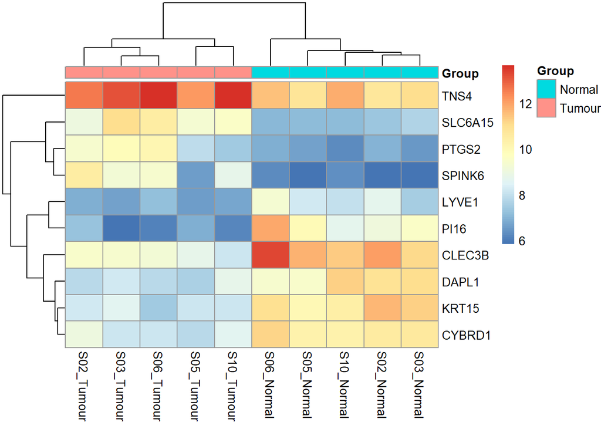

```r
#The heatmap
pheatmap(top10_vstObj, cluster_rows = T, cluster_cols = T, annotation_col = column_ann_df)
```

Focusing on SLC6A15 which is the most differentially expressed gene, it’s evident that the gene is expressed at low levels in normal cells, in contrast to tumour cells.

## Gene Set Enrichment Analysis

For this next section, I conducted Pre-ranked Gene Set Enrichment Analysis to determine which gene sets are significantly expressed. I used the C5 Gene Ontology Biological Processes gene sets dataset to illustrate the biological functions that exhibit significant differences in the tumour and normal samples.

```r
gmt_file <- read.gmt("omics_data/c5.go.bp.v7.4.symbols.gmt") # Loading the C5 GO BP
```

Ranking the DESEq2 data based on decreasing log2FoldChange (highest to lowest).

```r
#Using the ashr shrunk results from the DESeq2 analysis
ranked_df_Ashr_res <- df_Ashr_res[order(df_Ashr_res$log2FoldChange, decreasing = T), ]

#Creating vector of log2FC with their corresponding gene name
the_dgeRanks <- setNames(ranked_df_Ashr_res$log2FoldChange, ranked_df_Ashr_res$gene)

the_dgeRanks <- the_dgeRanks[!is.na(names(the_dgeRanks))] #Removing pathways with NA values
the_dgeRanks <- the_dgeRanks[!duplicated(names(the_dgeRanks))] #Removing duplicate pathways

head(the_dgeRanks, n=10)
```

```
##   SPINK6   DEFB4B    PTHLH    MMP10      OSM      SST    MMP13    CXCL8
## 6.684848 5.351471 5.334010 5.201934 5.193867 5.008519 4.834619 4.483527
##    CNGB1   DEFB4A
## 4.432534 4.413191
```

Running fgsea (fast gene set enrichment analysis). For minSize and maxSize parameters, these correspond to a range that I chose to explore. Testing for 15-500 gene sets.

```r
#Using set.seed so that output of fgsea is reproducible
set.seed(12345)

#Running the pre-ranked GSEA
fgsea_Results <- fgsea(pathways = gmt_file, stats = the_dgeRanks, minSize = 15, maxSize = 500)
head(fgsea_Results)
```

```
##                                   pathway        pval       padj    log2err
##                                    <char>       <num>      <num>      <num>
## 1:   GOBP_ACETYL_COA_BIOSYNTHETIC_PROCESS 0.088353414 0.37236227 0.17232434
## 2:      GOBP_ACETYL_COA_METABOLIC_PROCESS 0.019627126 0.17513433 0.35248786
## 3:       GOBP_ACIDIC_AMINO_ACID_TRANSPORT 0.388190955 0.73732967 0.06831109
## 4: GOBP_ACTIN_CYTOSKELETON_REORGANIZATION 0.475192944 0.79528986 0.05248276
## 5:     GOBP_ACTIN_FILAMENT_BASED_MOVEMENT 0.001242826 0.03697291 0.45505987
## 6:    GOBP_ACTIN_FILAMENT_BASED_TRANSPORT 0.246963563 0.60695847 0.09656296
##            ES       NES  size                                  leadingEdge
##         <num>     <num> <int>                                       <list>
## 1: -0.5485794 -1.385952    20      ACSS2,PDK4,PDHB,DLAT,GSTZ1,PPCS,...[14]
## 2: -0.5541937 -1.557806    33     ACSS2,PDK4,HMGCS1,MVK,ACACB,PDHB,...[16]
## 3: -0.3751170 -1.060828    34  GLS2,ATP1A2,NTRK2,GJA1,SLC12A2,PER2,...[14]
## 4: -0.3050898 -1.003005    89 CCL27,FGF7,CD2AP,FGF10,SEMA3E,IQGAP2,...[12]
## 5: -0.5030729 -1.645855    87  ANK2,CACNB2,ATP1A2,TMOD1,PKP2,GPD1L,...[30]
## 6: -0.4933091 -1.188331    16  MYO1D,SYNE2,FNBP1L,MYO5B,MYO5C,ACTN4,...[7]
```

### Top 10 differentially regulated BP gene sets based on padj value

```r
sorted_fgseaRes <- fgsea_Results |>
  arrange(padj) |> filter(padj < 0.05) |> slice_head(n = 10)

sorted_fgseaRes
```

```
##                                             pathway         pval         padj
##                                              <char>        <num>        <num>
##  1:      GOBP_MONOCARBOXYLIC_ACID_METABOLIC_PROCESS 3.738636e-14 1.263659e-10
##  2:               GOBP_FATTY_ACID_METABOLIC_PROCESS 8.933214e-13 1.509713e-09
##  3: GOBP_ORGANIC_HYDROXY_COMPOUND_METABOLIC_PROCESS 4.611626e-12 5.195765e-09
##  4:                    GOBP_LIPID_CATABOLIC_PROCESS 3.933953e-10 3.324190e-07
##  5:                  GOBP_ALCOHOL_METABOLIC_PROCESS 5.081948e-09 2.862831e-06
##  6:             GOBP_ORGANIC_ACID_CATABOLIC_PROCESS 4.384465e-09 2.862831e-06
##  7:                  GOBP_STEROID_METABOLIC_PROCESS 1.585808e-08 7.657187e-06
##  8:           GOBP_CELLULAR_LIPID_CATABOLIC_PROCESS 8.408779e-08 3.552709e-05
##  9:              GOBP_DEFENSE_RESPONSE_TO_BACTERIUM 2.232087e-07 7.544456e-05
## 10:        GOBP_SMALL_MOLECULE_BIOSYNTHETIC_PROCESS 2.018905e-07 7.544456e-05
##       log2err         ES       NES  size
##         <num>      <num>     <num> <int>
##  1: 0.9653278 -0.5019931 -1.853730   447
```

[output cut: 21 more lines]

## GSEA Enrichment plots

Normalised Enrichment Score (NES):

- Positive value = UPREGULATED PATHWAY of the test condition
- Negative value = DOWNREGULATED PATHWAY of the test condition

```r
#Extracting pathways with significant enrichment value
#Arranging by padj, then keeping only values with padj < 0.05, then extracting pathway names

sig_pathways <- fgsea_Results[order(padj)]
sig_pathways <- sig_pathways |> filter(padj < 0.05)

head(sig_pathways, n = 10)
```

```
##                                             pathway         pval         padj
##                                              <char>        <num>        <num>
##  1:      GOBP_MONOCARBOXYLIC_ACID_METABOLIC_PROCESS 3.738636e-14 1.263659e-10
##  2:               GOBP_FATTY_ACID_METABOLIC_PROCESS 8.933214e-13 1.509713e-09
##  3: GOBP_ORGANIC_HYDROXY_COMPOUND_METABOLIC_PROCESS 4.611626e-12 5.195765e-09
##  4:                    GOBP_LIPID_CATABOLIC_PROCESS 3.933953e-10 3.324190e-07
##  5:                  GOBP_ALCOHOL_METABOLIC_PROCESS 5.081948e-09 2.862831e-06
##  6:             GOBP_ORGANIC_ACID_CATABOLIC_PROCESS 4.384465e-09 2.862831e-06
##  7:                  GOBP_STEROID_METABOLIC_PROCESS 1.585808e-08 7.657187e-06
##  8:           GOBP_CELLULAR_LIPID_CATABOLIC_PROCESS 8.408779e-08 3.552709e-05
##  9:              GOBP_DEFENSE_RESPONSE_TO_BACTERIUM 2.232087e-07 7.544456e-05
## 10:        GOBP_SMALL_MOLECULE_BIOSYNTHETIC_PROCESS 2.018905e-07 7.544456e-05
##       log2err         ES       NES  size
##         <num>      <num>     <num> <int>
##  1: 0.9653278 -0.5019931 -1.853730   447
```

[output cut: 21 more lines]

```r
top2 <- sig_pathways |> arrange(desc(NES)) |> slice_head(n=2)
top2
```

```
##                                          pathway         pval         padj
##                                           <char>        <num>        <num>
## 1:        GOBP_B_CELL_RECEPTOR_SIGNALING_PATHWAY 8.111480e-07 0.0001713550
## 2: GOBP_POSITIVE_REGULATION_OF_B_CELL_ACTIVATION 1.428326e-06 0.0002682078
##      log2err        ES      NES  size
##        <num>     <num>    <num> <int>
## 1: 0.6594444 0.5285639 2.229281    75
## 2: 0.6435518 0.5048604 2.162156    80
##                                           leadingEdge
##                                                <list>
## 1: IGHV2-5,IGHV3-33,IGHV5-51,MS4A1,IGLC3,IGHM,...[21]
## 2: IGHV2-5,IGHV3-33,IGHV5-51,IGLC3,IGHM,IGHG4,...[21]
```

```r
down2 <- sig_pathways |> arrange(NES) |> slice_head(n=2)
down2
```

```
##                              pathway         pval         padj   log2err
##                               <char>        <num>        <num>     <num>
## 1: GOBP_FATTY_ACID_METABOLIC_PROCESS 8.933214e-13 1.509713e-09 0.9214260
## 2:              GOBP_LIPID_OXIDATION 3.666040e-07 1.084411e-04 0.6749629
##            ES       NES  size                              leadingEdge
##         <num>     <num> <int>                                   <list>
## 1: -0.5443012 -1.977534   277  ADIPOQ,HAO2,SCD,C3,CYP1B1,CRAT,...[113]
## 2: -0.5991325 -1.975140    92 ADIPOQ,HAO2,APOD,CRAT,PPARG,PECR,...[39]
```

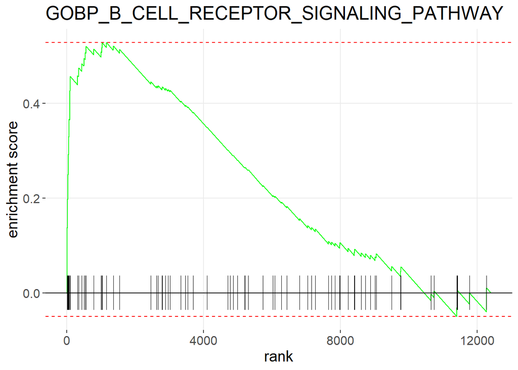

```r
upreg1 <- plotEnrichment(pathway = gmt_file[[top2$pathway[1]]],
                               stats = the_dgeRanks) + labs(title = top2$pathway[1]) +
                                                                   theme(text = element_text(size = 15))

upreg2 <- plotEnrichment(pathway = gmt_file[[top2$pathway[2]]],
                               stats = the_dgeRanks) + labs(title = top2$pathway[2]) +
                                                                  theme(text = element_text(size = 15))

#Display the enrichment plots
upreg1
```

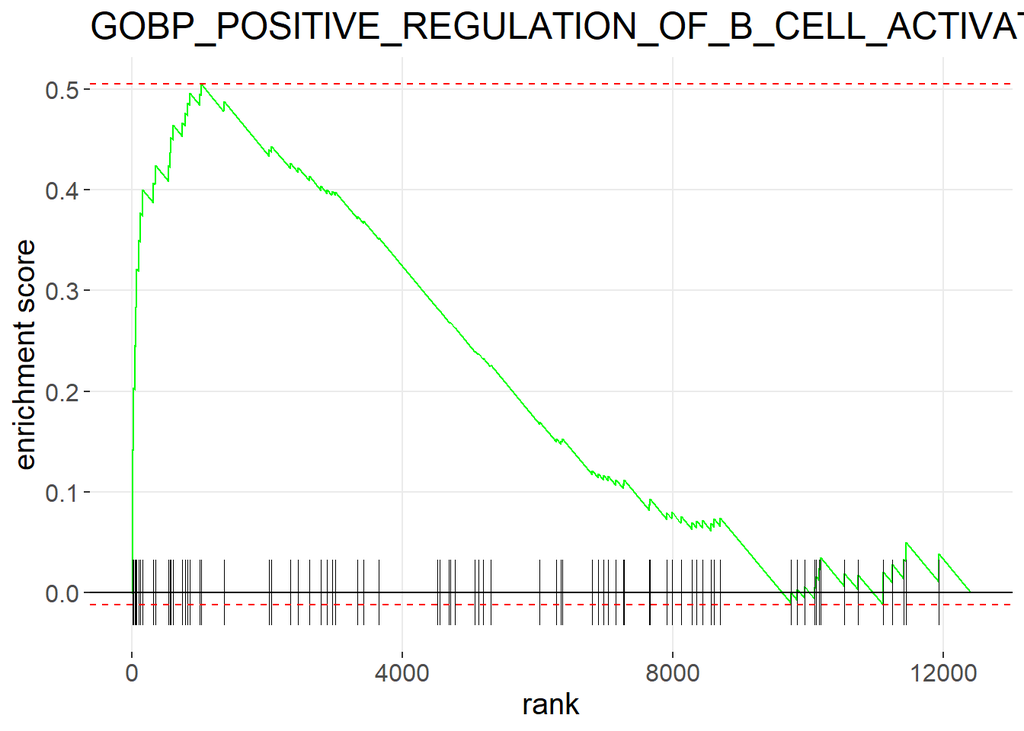

```r
upreg2
```

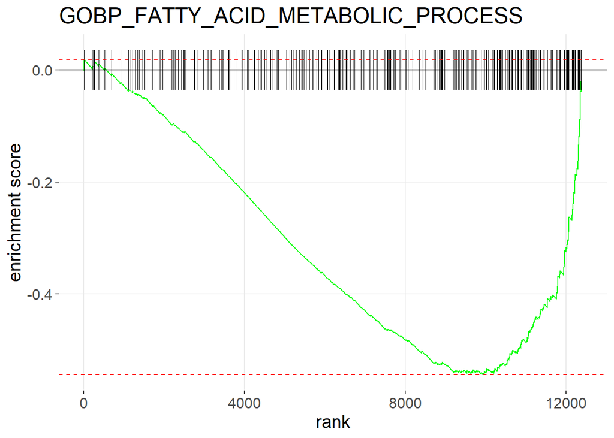

```r
downreg1 <- plotEnrichment(pathway = gmt_file[[down2$pathway[1]]],
                               stats = the_dgeRanks) + labs(title = down2$pathway[1]) +
                                                                   theme(text = element_text(size = 15))

downreg2 <- plotEnrichment(pathway = gmt_file[[down2$pathway[2]]],
                               stats = the_dgeRanks) + labs(title = down2$pathway[2]) +
                                                                  theme(text = element_text(size = 15))

#Display the enrichment plots
downreg1
```

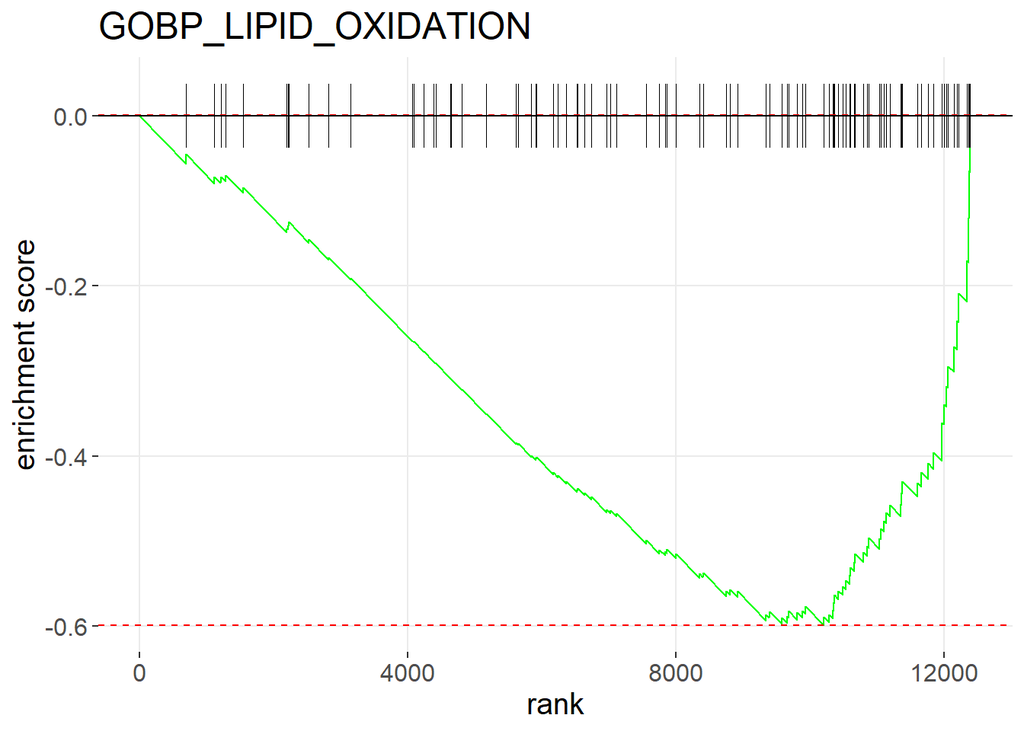

```r
downreg2
```